# Student Details

**Student ID Numbers and Names of Group Members**

1. 122790 - C - Bwalley Nicholas
2. 133834 - C - Mongare Sarah
3. 133928 - C - Cheptoi Millicent
4. 134879 - C - Tulienge Lesley
5. 124461 - C - Kinya Angela

**GitHub Classroom Group Name**

Acers Team

**Course Code**

BBT4206

**Course Name**

Business Intelligence II

**Program**

Bachelor of Business Information Technology

**Semester Duration**

21<sup>st</sup> August 2023 to 28<sup>th</sup> November 2023

# Understanding the Dataset (Exploratory Data Analysis (EDA))

## Loading the Dataset

### Source:

The dataset that was used can be downloaded here: https://www.kaggle.com/datasets/bharath011/heart-disease-classification-dataset*

### Reference:

# STEP 1. Install and Load the Required Packages —-

```r
## ggplot2 ----
if (require("ggplot2")) {
  require("ggplot2")
} else {
  install.packages("ggplot2", dependencies = TRUE,
                   repos = "https://cloud.r-project.org")
}
## caret ----
if (require("caret")) {
  require("caret")
} else {
  install.packages("caret", dependencies = TRUE,
                   repos = "https://cloud.r-project.org")
}
## mlbench ----
if (require("mlbench")) {
  require("mlbench")
} else {
  install.packages("mlbench", dependencies = TRUE,
                   repos = "https://cloud.r-project.org")
}
## pROC ----
if (require("pROC")) {
  require("pROC")
} else {
  install.packages("pROC", dependencies = TRUE,
                   repos = "https://cloud.r-project.org")
}
## dplyr ----
if (require("dplyr")) {
  require("dplyr")
} else {
  install.packages("dplyr", dependencies = TRUE,
                   repos = "https://cloud.r-project.org")
}
```

# 1. Accuracy and Cohen’s Kappa —-

## 1.a. Load the dataset —-

```r
library(readr)
heart_attack_dataset <- read_csv("C:/Users/NICK BWALLEY/OneDrive - Strathmore University/MyStrath/BBIT/4.2/Business Intelligence II - Dr. Allan Omondi/BI2-Labs/BBT4206-R-Lab6of15-EvaluationMetrics-acers_team/data/heart_attack_dataset.csv")
View(heart_attack_dataset)
# data(heart_attack_dataset)
# sapply(heart_attack_dataset, class) #datatypes of variables


## 1.b. Determine the Baseline Accuracy ----
heart_attack_dataset_freq <- heart_attack_dataset$class
cbind(frequency =
        table(heart_attack_dataset_freq),
      percentage = prop.table(table(heart_attack_dataset_freq)) * 100)
```

```
##          frequency percentage
## negative       509   38.58984
## positive       810   61.41016
```

```r
## 1.c. Split the dataset ----
# Define a 75:25 train:test data split of the dataset.
# That is, 75% of the original data will be used to train the model and
# 25% of the original data will be used to test the model.
train_index <- createDataPartition(heart_attack_dataset$class,
                                   p = 0.75,
                                   list = FALSE)
heart_attack_dataset_train <- heart_attack_dataset[train_index, ]
heart_attack_dataset_test <- heart_attack_dataset[-train_index, ]


## 1.d. Train the Model ----
# We apply the 5-fold cross validation resampling method
train_control <- trainControl(method = "cv", number = 5)


# `set.seed()` is a function that is used to specify a starting point for the
# random number generator to a specific value. This ensures that every time you
# run the same code, you will get the same "random" numbers.
set.seed(7) #you can use any values the point is to introduce the randomness
class_model_glm <-
  train(class ~ ., data = heart_attack_dataset_train, method = "glm",
        metric = "Accuracy", trControl = train_control) #all other variables ~ .
## 1.e. Display the Model's Performance ----
### Option 1: Use the metric calculated by caret when training the model ----
print(class_model_glm)
```

```
## Generalized Linear Model
##
## 990 samples
##   8 predictor
##   2 classes: 'negative', 'positive'
##
## No pre-processing
## Resampling: Cross-Validated (5 fold)
## Summary of sample sizes: 792, 791, 792, 793, 792
## Resampling results:
##
##   Accuracy   Kappa
##   0.8252609  0.6360275
```

# 2. RMSE, R Squared, and MAE —-

```r
# PLEASE NOTE:
## THIS STEP IS NOT APPLICABLE IN OUR DATASET SO IN THIS SECTION WE ARE NOT GOING TO PERFORM THE COMPUTATIONS IN THIS SECTION.
```

# 3. Area Under ROC Curve —-

Area Under Receiver Operating Characteristic Curve (AUROC) or simply “Area Under Curve (AUC)” or “ROC” represents a model’s ability to discriminate between two classes.

```r
## 3.b. Determine the Baseline Accuracy ----
heart_attack_dataset_freq <- heart_attack_dataset$class
cbind(frequency =
        table(heart_attack_dataset_freq),
      percentage = prop.table(table(heart_attack_dataset_freq)) * 100)
```

```
##          frequency percentage
## negative       509   38.58984
## positive       810   61.41016
```

```r
## 3.c. Split the dataset ----
# Define an 80:20 train:test data split of the dataset.
train_index <- createDataPartition(heart_attack_dataset$class,
                                   p = 0.8,
                                   list = FALSE)
heart_attack_dataset_train <- heart_attack_dataset[train_index, ]
heart_attack_dataset_test <- heart_attack_dataset[-train_index, ]

## 3.d. Train the Model ----
# We apply the 10-fold cross validation resampling method
train_control <- trainControl(method = "cv", number = 10,
                              classProbs = TRUE,
                              summaryFunction = twoClassSummary)


set.seed(7)
class_model_knn <-
  train(class ~ ., data = heart_attack_dataset_train, method = "knn",
        metric = "ROC", trControl = train_control)

## 3.e. Display the Model's Performance ----
### Option 1: Use the metric calculated by caret when training the model ----

print(class_model_knn)
```

```
## k-Nearest Neighbors
##
## 1056 samples
##    8 predictor
##    2 classes: 'negative', 'positive'
##
## No pre-processing
## Resampling: Cross-Validated (10 fold)
## Summary of sample sizes: 950, 951, 950, 951, 950, 950, ...
## Resampling results across tuning parameters:
##
##   k  ROC        Sens       Spec
##   5  0.6389927  0.4876829  0.6788462
##   7  0.6527297  0.4510976  0.7267067
##   9  0.6696653  0.4682317  0.7467308
##
## ROC was used to select the optimal model using the largest value.
## The final value used for the model was k = 9.
```

```r
#### AUC ----
# The type = "prob" argument specifies that you want to obtain class
# probabilities as the output of the prediction instead of class labels.
predictions <- predict(class_model_knn, heart_attack_dataset_test[, 1:8],
                       type = "prob")


print(predictions)
```

[output not shown]

[output cut: 249 more lines]

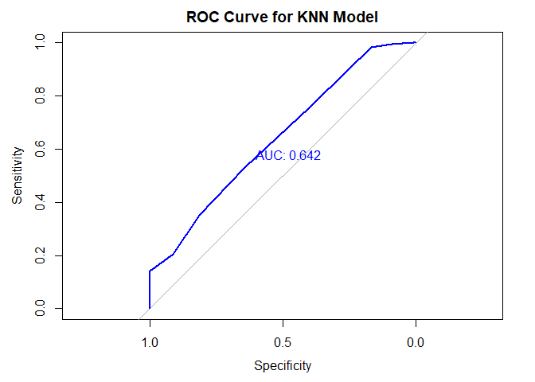

```r
roc_curve <- roc(heart_attack_dataset_test$class, predictions$neg)
# Plot the ROC curve
plot(roc_curve, main = "ROC Curve for KNN Model", print.auc = TRUE,
     print.auc.x = 0.6, print.auc.y = 0.6, col = "blue", lwd = 2.5)
```

# 4. Logarithmic Loss (LogLoss) —-

```r
## 4.a. Load the dataset ----
## 4.b. Train the Model ----
# We apply the 5-fold repeated cross validation resampling method
# with 3 repeats
train_control <- trainControl(method = "repeatedcv", number = 5, repeats = 3,
                              classProbs = TRUE,
                              summaryFunction = mnLogLoss)
set.seed(7)


heart_model_cart <- train(class ~ ., data = heart_attack_dataset, method = "rpart",
                         metric = "logLoss", trControl = train_control)

## 4.c. Display the Model's Performance ----
### Option 1: Use the metric calculated by caret when training the model ----

print(heart_model_cart)
```

```
## CART
##
## 1319 samples
##    8 predictor
##    2 classes: 'negative', 'positive'
##
## No pre-processing
## Resampling: Cross-Validated (5 fold, repeated 3 times)
## Summary of sample sizes: 1056, 1055, 1055, 1055, 1055, 1055, ...
## Resampling results across tuning parameters:
##
##   cp           logLoss
##   0.006876228  0.1637674
##   0.294695481  0.2193278
##   0.671905697  0.5320587
##
## logLoss was used to select the optimal model using the smallest value.
## The final value used for the model was cp = 0.006876228.
```

# 5. References —-

```r
## Kuhn, M., Wing, J., Weston, S., Williams, A., Keefer, C., Engelhardt, A., Cooper, T., Mayer, Z., Kenkel, B., R Core Team, Benesty, M., Lescarbeau, R., Ziem, A., Scrucca, L., Tang, Y., Candan, C., & Hunt, T. (2023). caret: Classification and Regression Training (6.0-94) [Computer software]. https://cran.r-project.org/package=caret # nolint ----

## Leisch, F., & Dimitriadou, E. (2023). mlbench: Machine Learning Benchmark Problems (2.1-3.1) [Computer software]. https://cran.r-project.org/web/packages/mlbench/index.html # nolint ----


## Robin, X., Turck, N., Hainard, A., Tiberti, N., Lisacek, F., Sanchez, J.-C., Müller, M., Siegert, S., Doering, M., & Billings, Z. (2023). pROC: Display and Analyze ROC Curves (1.18.4) [Computer software]. https://cran.r-project.org/web/packages/pROC/index.html # nolint ----

## Wickham, H., François, R., Henry, L., Müller, K., Vaughan, D., Software, P., & PBC. (2023). dplyr: A Grammar of Data Manipulation (1.1.3) [Computer software]. https://cran.r-project.org/package=dplyr # nolint ----

## Wickham, H., Chang, W., Henry, L., Pedersen, T. L., Takahashi, K., Wilke, C., Woo, K., Yutani, H., Dunnington, D., Posit, & PBC. (2023). ggplot2: Create Elegant Data Visualisations Using the Grammar of Graphics (3.4.3) [Computer software]. https://cran.r-project.org/package=ggplot2 # nolint ----
```